# Risk Factor Analysis

## Outcome Variable

**Outcome Variable:** wasted

## Predictor Variables

**Intervention Variable:** exclfeed3

**Adjustment Set:**

- arm
- sex
- brthmon
- W_mage
- meducyrs
- feducyrs
- hhwealth_quart
- hfoodsec
- W_mhtcm
- W_mwtkg
- W_mbmi
- vagbrth
- W_gagebrth
- W_birthwt
- W_birthlen
- W_nrooms
- W_nchldlt5
- month
- W_parity
- impfloor
- impsan
- safeh20
- delta_W_mage
- delta_meducyrs
- delta_feducyrs
- delta_hhwealth_quart
- delta_hfoodsec
- delta_W_mhtcm
- delta_W_mwtkg
- delta_W_mbmi
- delta_vagbrth
- delta_W_gagebrth
- delta_W_birthwt
- delta_W_birthlen
- delta_W_nrooms
- delta_W_nchldlt5
- delta_month
- delta_W_parity
- delta_impfloor
- delta_impsan
- delta_safeh20

## Stratifying Variables

The analysis was stratified on these variable(s):

- agecat
- studyid
- country

## Data Summary

| agecat | studyid | country | exclfeed3 | wasted | n_cell | n |
| --- | --- | --- | --- | --- | --- | --- |
| Birth | CMC-V-BCS-2002 | INDIA | 1 | 0 | 4 | 4 |
| Birth | CMC-V-BCS-2002 | INDIA | 1 | 1 | 0 | 4 |
| Birth | CMC-V-BCS-2002 | INDIA | 0 | 0 | 0 | 4 |
| Birth | CMC-V-BCS-2002 | INDIA | 0 | 1 | 0 | 4 |
| Birth | EE | PAKISTAN | 1 | 0 | 18 | 22 |
| Birth | EE | PAKISTAN | 1 | 1 | 4 | 22 |
| Birth | EE | PAKISTAN | 0 | 0 | 0 | 22 |
| Birth | EE | PAKISTAN | 0 | 1 | 0 | 22 |
| Birth | GMS-Nepal | NEPAL | 1 | 0 | 282 | 422 |
| Birth | GMS-Nepal | NEPAL | 1 | 1 | 70 | 422 |
| Birth | GMS-Nepal | NEPAL | 0 | 0 | 60 | 422 |
| Birth | GMS-Nepal | NEPAL | 0 | 1 | 10 | 422 |
| Birth | IRC | INDIA | 1 | 0 | 0 | 9 |
| Birth | IRC | INDIA | 1 | 1 | 0 | 9 |
| Birth | IRC | INDIA | 0 | 0 | 6 | 9 |
| Birth | IRC | INDIA | 0 | 1 | 3 | 9 |
| Birth | JiVitA-3 | BANGLADESH | 1 | 0 | 8558 | 10634 |
| Birth | JiVitA-3 | BANGLADESH | 1 | 1 | 1078 | 10634 |
| Birth | JiVitA-3 | BANGLADESH | 0 | 0 | 898 | 10634 |
| Birth | JiVitA-3 | BANGLADESH | 0 | 1 | 100 | 10634 |
| Birth | JiVitA-4 | BANGLADESH | 1 | 0 | 87 | 97 |
| Birth | JiVitA-4 | BANGLADESH | 1 | 1 | 2 | 97 |
| Birth | JiVitA-4 | BANGLADESH | 0 | 0 | 8 | 97 |
| Birth | JiVitA-4 | BANGLADESH | 0 | 1 | 0 | 97 |
| Birth | Keneba | GAMBIA | 1 | 0 | 858 | 1282 |
| Birth | Keneba | GAMBIA | 1 | 1 | 275 | 1282 |
| Birth | Keneba | GAMBIA | 0 | 0 | 102 | 1282 |
| Birth | Keneba | GAMBIA | 0 | 1 | 47 | 1282 |
| Birth | MAL-ED | BANGLADESH | 1 | 0 | 109 | 202 |
| Birth | MAL-ED | BANGLADESH | 1 | 1 | 21 | 202 |

[output cut: 158 more lines]

The following strata were considered:

- agecat: 24 months, studyid: CMC-V-BCS-2002, country: INDIA
- agecat: 24 months, studyid: EE, country: PAKISTAN
- agecat: 24 months, studyid: GMS-Nepal, country: NEPAL
- agecat: 24 months, studyid: IRC, country: INDIA
- agecat: 24 months, studyid: JiVitA-3, country: BANGLADESH
- agecat: 24 months, studyid: JiVitA-4, country: BANGLADESH
- agecat: 24 months, studyid: Keneba, country: GAMBIA
- agecat: 24 months, studyid: MAL-ED, country: BANGLADESH
- agecat: 24 months, studyid: MAL-ED, country: BRAZIL
- agecat: 24 months, studyid: MAL-ED, country: INDIA
- agecat: 24 months, studyid: MAL-ED, country: NEPAL
- agecat: 24 months, studyid: MAL-ED, country: PERU
- agecat: 24 months, studyid: MAL-ED, country: SOUTH AFRICA
- agecat: 24 months, studyid: MAL-ED, country: TANZANIA, UNITED REPUBLIC OF
- agecat: 24 months, studyid: PROVIDE, country: BANGLADESH
- agecat: 6 months, studyid: CMC-V-BCS-2002, country: INDIA
- agecat: 6 months, studyid: EE, country: PAKISTAN
- agecat: 6 months, studyid: GMS-Nepal, country: NEPAL
- agecat: 6 months, studyid: IRC, country: INDIA
- agecat: 6 months, studyid: JiVitA-3, country: BANGLADESH
- agecat: 6 months, studyid: JiVitA-4, country: BANGLADESH
- agecat: 6 months, studyid: Keneba, country: GAMBIA
- agecat: 6 months, studyid: MAL-ED, country: BANGLADESH
- agecat: 6 months, studyid: MAL-ED, country: BRAZIL
- agecat: 6 months, studyid: MAL-ED, country: INDIA
- agecat: 6 months, studyid: MAL-ED, country: NEPAL
- agecat: 6 months, studyid: MAL-ED, country: PERU
- agecat: 6 months, studyid: MAL-ED, country: SOUTH AFRICA
- agecat: 6 months, studyid: MAL-ED, country: TANZANIA, UNITED REPUBLIC OF
- agecat: 6 months, studyid: PROVIDE, country: BANGLADESH
- agecat: 6 months, studyid: SAS-CompFeed, country: INDIA
- agecat: Birth, studyid: CMC-V-BCS-2002, country: INDIA
- agecat: Birth, studyid: EE, country: PAKISTAN
- agecat: Birth, studyid: GMS-Nepal, country: NEPAL
- agecat: Birth, studyid: IRC, country: INDIA
- agecat: Birth, studyid: JiVitA-3, country: BANGLADESH
- agecat: Birth, studyid: JiVitA-4, country: BANGLADESH
- agecat: Birth, studyid: Keneba, country: GAMBIA
- agecat: Birth, studyid: MAL-ED, country: BANGLADESH
- agecat: Birth, studyid: MAL-ED, country: BRAZIL
- agecat: Birth, studyid: MAL-ED, country: INDIA
- agecat: Birth, studyid: MAL-ED, country: NEPAL
- agecat: Birth, studyid: MAL-ED, country: PERU
- agecat: Birth, studyid: MAL-ED, country: SOUTH AFRICA
- agecat: Birth, studyid: MAL-ED, country: TANZANIA, UNITED REPUBLIC OF
- agecat: Birth, studyid: PROVIDE, country: BANGLADESH
- agecat: Birth, studyid: SAS-CompFeed, country: INDIA

### Dropped Strata

Some strata were dropped due to rare outcomes:

- agecat: Birth, studyid: CMC-V-BCS-2002, country: INDIA
- agecat: Birth, studyid: EE, country: PAKISTAN
- agecat: Birth, studyid: IRC, country: INDIA
- agecat: Birth, studyid: JiVitA-4, country: BANGLADESH
- agecat: Birth, studyid: MAL-ED, country: BRAZIL
- agecat: Birth, studyid: MAL-ED, country: INDIA
- agecat: Birth, studyid: MAL-ED, country: NEPAL
- agecat: Birth, studyid: MAL-ED, country: PERU
- agecat: Birth, studyid: MAL-ED, country: SOUTH AFRICA
- agecat: Birth, studyid: MAL-ED, country: TANZANIA, UNITED REPUBLIC OF
- agecat: Birth, studyid: SAS-CompFeed, country: INDIA
- agecat: 6 months, studyid: CMC-V-BCS-2002, country: INDIA
- agecat: 6 months, studyid: EE, country: PAKISTAN
- agecat: 6 months, studyid: IRC, country: INDIA
- agecat: 6 months, studyid: JiVitA-4, country: BANGLADESH
- agecat: 6 months, studyid: MAL-ED, country: BANGLADESH
- agecat: 6 months, studyid: MAL-ED, country: BRAZIL
- agecat: 6 months, studyid: MAL-ED, country: NEPAL
- agecat: 6 months, studyid: MAL-ED, country: PERU
- agecat: 6 months, studyid: MAL-ED, country: SOUTH AFRICA
- agecat: 6 months, studyid: MAL-ED, country: TANZANIA, UNITED REPUBLIC OF
- agecat: 6 months, studyid: SAS-CompFeed, country: INDIA
- agecat: 24 months, studyid: CMC-V-BCS-2002, country: INDIA
- agecat: 24 months, studyid: EE, country: PAKISTAN
- agecat: 24 months, studyid: IRC, country: INDIA
- agecat: 24 months, studyid: JiVitA-4, country: BANGLADESH
- agecat: 24 months, studyid: MAL-ED, country: BANGLADESH
- agecat: 24 months, studyid: MAL-ED, country: BRAZIL
- agecat: 24 months, studyid: MAL-ED, country: NEPAL
- agecat: 24 months, studyid: MAL-ED, country: PERU
- agecat: 24 months, studyid: MAL-ED, country: SOUTH AFRICA
- agecat: 24 months, studyid: MAL-ED, country: TANZANIA, UNITED REPUBLIC OF

## Methods Detail

We’re interested in the causal parameters $E[Y_a]$ for all values of $a \in \mathcal{A}$. These parameters represent the mean outcome if, possibly contrary to fact, we intervened to set all units to have $A=a$. Under the randomization and positivity assumptions, these are identified by the statistical parameters $\psi_a=E_W[E_{Y|A,W}(Y|A=a,W)]$. In addition, we’re interested in the mean of $Y$, $E[Y]$ under no intervention (the observed mean). We will estimate these parameters by using SuperLearner to fit the relevant likelihood factors – $E_{Y|A,W}(Y|A=a,W)$ and $p(A=a|W)$, and then updating our likelihood fit using a joint TMLE.

For unadjusted analyses ($W=\{\}$), initial likelihoods were estimated using Lrnr_glm to estimate the simple $E(Y|A)$ and Lrnr_mean to estimate $p(A)$. For adjusted analyses, a small library containing Lrnr_glmnet, Lrnr_xgboost, and Lrnr_mean was used.

Having estimated these parameters, we will then use the delta method to estimate relative risks and attributable risks relative to a prespecified baseline level of $A$.

# Results Detail

## Results Plots

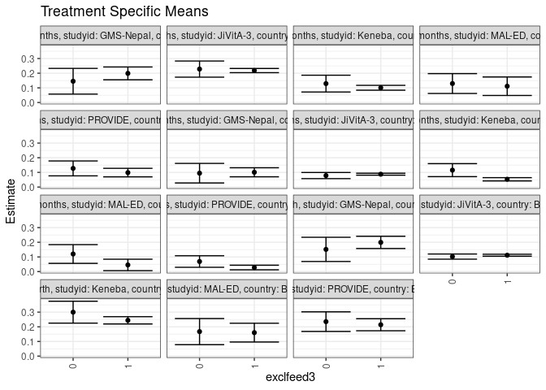

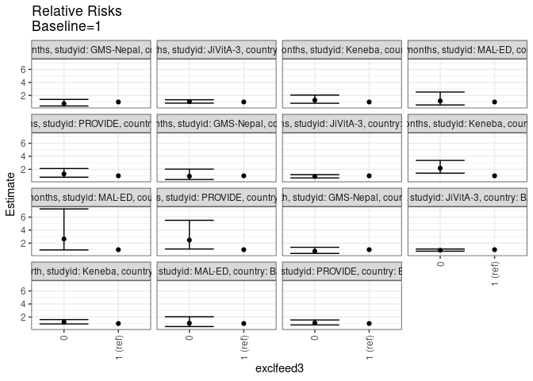

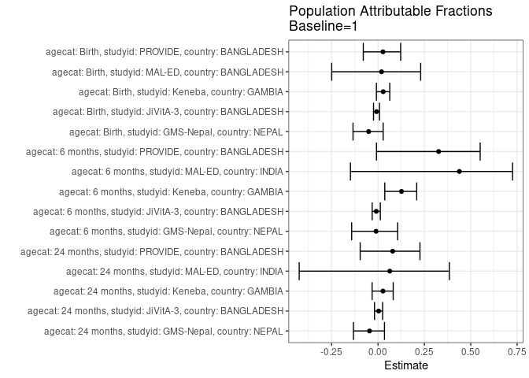

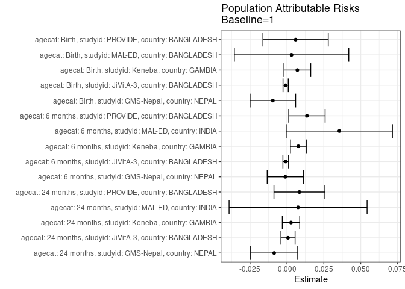

## Results Table

### Parameter: TSM

| agecat | studyid | country | intervention_level | baseline_level | estimate | ci_lower | ci_upper |
| --- | --- | --- | --- | --- | --- | --- | --- |
| Birth | GMS-Nepal | NEPAL | 1 | NA | 0.1991209 | 0.1573730 | 0.2408688 |
| Birth | GMS-Nepal | NEPAL | 0 | NA | 0.1514429 | 0.0689938 | 0.2338920 |
| Birth | JiVitA-3 | BANGLADESH | 1 | NA | 0.1116518 | 0.1048901 | 0.1184136 |
| Birth | JiVitA-3 | BANGLADESH | 0 | NA | 0.1023605 | 0.0847550 | 0.1199659 |
| Birth | Keneba | GAMBIA | 1 | NA | 0.2441122 | 0.2192223 | 0.2690021 |
| Birth | Keneba | GAMBIA | 0 | NA | 0.2997389 | 0.2251107 | 0.3743671 |
| Birth | MAL-ED | BANGLADESH | 1 | NA | 0.1602422 | 0.0962978 | 0.2241866 |
| Birth | MAL-ED | BANGLADESH | 0 | NA | 0.1672204 | 0.0781854 | 0.2562554 |
| Birth | PROVIDE | BANGLADESH | 1 | NA | 0.2140632 | 0.1729763 | 0.2551502 |
| Birth | PROVIDE | BANGLADESH | 0 | NA | 0.2351664 | 0.1682834 | 0.3020493 |
| 6 months | GMS-Nepal | NEPAL | 1 | NA | 0.1008174 | 0.0699785 | 0.1316564 |
| 6 months | GMS-Nepal | NEPAL | 0 | NA | 0.0945946 | 0.0278402 | 0.1613490 |
| 6 months | JiVitA-3 | BANGLADESH | 1 | NA | 0.0877051 | 0.0810134 | 0.0943967 |
| 6 months | JiVitA-3 | BANGLADESH | 0 | NA | 0.0784186 | 0.0575547 | 0.0992825 |
| 6 months | Keneba | GAMBIA | 1 | NA | 0.0531354 | 0.0419245 | 0.0643463 |
| 6 months | Keneba | GAMBIA | 0 | NA | 0.1153647 | 0.0710274 | 0.1597019 |
| 6 months | MAL-ED | INDIA | 1 | NA | 0.0454545 | 0.0064356 | 0.0844735 |
| 6 months | MAL-ED | INDIA | 0 | NA | 0.1200000 | 0.0561565 | 0.1838435 |
| 6 months | PROVIDE | BANGLADESH | 1 | NA | 0.0279041 | 0.0121991 | 0.0436091 |
| 6 months | PROVIDE | BANGLADESH | 0 | NA | 0.0688087 | 0.0294958 | 0.1081216 |
| 24 months | GMS-Nepal | NEPAL | 1 | NA | 0.1987578 | 0.1551132 | 0.2424023 |
| 24 months | GMS-Nepal | NEPAL | 0 | NA | 0.1451613 | 0.0573630 | 0.2329596 |
| 24 months | JiVitA-3 | BANGLADESH | 1 | NA | 0.2179748 | 0.2037050 | 0.2322447 |
| 24 months | JiVitA-3 | BANGLADESH | 0 | NA | 0.2280780 | 0.1730700 | 0.2830861 |
| 24 months | Keneba | GAMBIA | 1 | NA | 0.1006879 | 0.0841503 | 0.1172255 |
| 24 months | Keneba | GAMBIA | 0 | NA | 0.1290445 | 0.0718218 | 0.1862672 |
| 24 months | MAL-ED | INDIA | 1 | NA | 0.1112553 | 0.0482478 | 0.1742628 |
| 24 months | MAL-ED | INDIA | 0 | NA | 0.1295532 | 0.0619026 | 0.1972038 |
| 24 months | PROVIDE | BANGLADESH | 1 | NA | 0.0986201 | 0.0695769 | 0.1276634 |
| 24 months | PROVIDE | BANGLADESH | 0 | NA | 0.1272853 | 0.0764607 | 0.1781098 |

### Parameter: E(Y)

| agecat | studyid | country | intervention_level | baseline_level | estimate | ci_lower | ci_upper |
| --- | --- | --- | --- | --- | --- | --- | --- |
| Birth | GMS-Nepal | NEPAL | NA | NA | 0.1895735 | 0.1521320 | 0.2270149 |
| Birth | JiVitA-3 | BANGLADESH | NA | NA | 0.1107768 | 0.1043978 | 0.1171557 |
| Birth | Keneba | GAMBIA | NA | NA | 0.2511700 | 0.2274208 | 0.2749193 |
| Birth | MAL-ED | BANGLADESH | NA | NA | 0.1633663 | 0.1122571 | 0.2144755 |
| Birth | PROVIDE | BANGLADESH | NA | NA | 0.2199248 | 0.1846953 | 0.2551543 |
| 6 months | GMS-Nepal | NEPAL | NA | NA | 0.0997732 | 0.0717702 | 0.1277763 |
| 6 months | JiVitA-3 | BANGLADESH | NA | NA | 0.0868958 | 0.0805887 | 0.0932029 |
| 6 months | Keneba | GAMBIA | NA | NA | 0.0608496 | 0.0496205 | 0.0720787 |
| 6 months | MAL-ED | INDIA | NA | NA | 0.0809524 | 0.0439731 | 0.1179317 |
| 6 months | PROVIDE | BANGLADESH | NA | NA | 0.0414594 | 0.0255348 | 0.0573839 |
| 24 months | GMS-Nepal | NEPAL | NA | NA | 0.1901042 | 0.1508072 | 0.2294011 |
| 24 months | JiVitA-3 | BANGLADESH | NA | NA | 0.2187047 | 0.2046312 | 0.2327783 |
| 24 months | Keneba | GAMBIA | NA | NA | 0.1034483 | 0.0876083 | 0.1192882 |
| 24 months | MAL-ED | INDIA | NA | NA | 0.1188119 | 0.0740803 | 0.1635435 |
| 24 months | PROVIDE | BANGLADESH | NA | NA | 0.1070812 | 0.0818727 | 0.1322897 |

### Parameter: RR

| agecat | studyid | country | intervention_level | baseline_level | estimate | ci_lower | ci_upper |
| --- | --- | --- | --- | --- | --- | --- | --- |
| Birth | GMS-Nepal | NEPAL | 1 | 1 | 1.0000000 | 1.0000000 | 1.000000 |
| Birth | GMS-Nepal | NEPAL | 0 | 1 | 0.7605574 | 0.4242080 | 1.363594 |
| Birth | JiVitA-3 | BANGLADESH | 1 | 1 | 1.0000000 | 1.0000000 | 1.000000 |
| Birth | JiVitA-3 | BANGLADESH | 0 | 1 | 0.9167826 | 0.7649099 | 1.098809 |
| Birth | Keneba | GAMBIA | 1 | 1 | 1.0000000 | 1.0000000 | 1.000000 |
| Birth | Keneba | GAMBIA | 0 | 1 | 1.2278735 | 0.9395314 | 1.604708 |
| Birth | MAL-ED | BANGLADESH | 1 | 1 | 1.0000000 | 1.0000000 | 1.000000 |
| Birth | MAL-ED | BANGLADESH | 0 | 1 | 1.0435478 | 0.5346788 | 2.036722 |
| Birth | PROVIDE | BANGLADESH | 1 | 1 | 1.0000000 | 1.0000000 | 1.000000 |
| Birth | PROVIDE | BANGLADESH | 0 | 1 | 1.0985837 | 0.7814565 | 1.544406 |
| 6 months | GMS-Nepal | NEPAL | 1 | 1 | 1.0000000 | 1.0000000 | 1.000000 |
| 6 months | GMS-Nepal | NEPAL | 0 | 1 | 0.9382761 | 0.4348109 | 2.024701 |
| 6 months | JiVitA-3 | BANGLADESH | 1 | 1 | 1.0000000 | 1.0000000 | 1.000000 |
| 6 months | JiVitA-3 | BANGLADESH | 0 | 1 | 0.8941174 | 0.6760463 | 1.182531 |
| 6 months | Keneba | GAMBIA | 1 | 1 | 1.0000000 | 1.0000000 | 1.000000 |
| 6 months | Keneba | GAMBIA | 0 | 1 | 2.1711450 | 1.4013036 | 3.363918 |
| 6 months | MAL-ED | INDIA | 1 | 1 | 1.0000000 | 1.0000000 | 1.000000 |
| 6 months | MAL-ED | INDIA | 0 | 1 | 2.6400000 | 0.9616175 | 7.247788 |
| 6 months | PROVIDE | BANGLADESH | 1 | 1 | 1.0000000 | 1.0000000 | 1.000000 |
| 6 months | PROVIDE | BANGLADESH | 0 | 1 | 2.4658970 | 1.1047789 | 5.503950 |
| 24 months | GMS-Nepal | NEPAL | 1 | 1 | 1.0000000 | 1.0000000 | 1.000000 |
| 24 months | GMS-Nepal | NEPAL | 0 | 1 | 0.7303427 | 0.3837740 | 1.389882 |
| 24 months | JiVitA-3 | BANGLADESH | 1 | 1 | 1.0000000 | 1.0000000 | 1.000000 |
| 24 months | JiVitA-3 | BANGLADESH | 0 | 1 | 1.0463503 | 0.8171199 | 1.339888 |
| 24 months | Keneba | GAMBIA | 1 | 1 | 1.0000000 | 1.0000000 | 1.000000 |
| 24 months | Keneba | GAMBIA | 0 | 1 | 1.2816292 | 0.7990918 | 2.055550 |
| 24 months | MAL-ED | INDIA | 1 | 1 | 1.0000000 | 1.0000000 | 1.000000 |
| 24 months | MAL-ED | INDIA | 0 | 1 | 1.1644675 | 0.5381699 | 2.519621 |
| 24 months | PROVIDE | BANGLADESH | 1 | 1 | 1.0000000 | 1.0000000 | 1.000000 |
| 24 months | PROVIDE | BANGLADESH | 0 | 1 | 1.2906620 | 0.7858107 | 2.119860 |

### Parameter: PAR

| agecat | studyid | country | intervention_level | baseline_level | estimate | ci_lower | ci_upper |
| --- | --- | --- | --- | --- | --- | --- | --- |
| Birth | GMS-Nepal | NEPAL | 1 | NA | -0.0095474 | -0.0249878 | 0.0058929 |
| Birth | JiVitA-3 | BANGLADESH | 1 | NA | -0.0008751 | -0.0026571 | 0.0009070 |
| Birth | Keneba | GAMBIA | 1 | NA | 0.0070578 | -0.0020023 | 0.0161180 |
| Birth | MAL-ED | BANGLADESH | 1 | NA | 0.0031241 | -0.0356640 | 0.0419123 |
| Birth | PROVIDE | BANGLADESH | 1 | NA | 0.0058616 | -0.0162752 | 0.0279984 |
| 6 months | GMS-Nepal | NEPAL | 1 | NA | -0.0010442 | -0.0133851 | 0.0112967 |
| 6 months | JiVitA-3 | BANGLADESH | 1 | NA | -0.0008093 | -0.0027264 | 0.0011079 |
| 6 months | Keneba | GAMBIA | 1 | NA | 0.0077142 | 0.0023247 | 0.0131036 |
| 6 months | MAL-ED | INDIA | 1 | NA | 0.0354978 | -0.0004879 | 0.0714835 |
| 6 months | PROVIDE | BANGLADESH | 1 | NA | 0.0135552 | 0.0012255 | 0.0258849 |
| 24 months | GMS-Nepal | NEPAL | 1 | NA | -0.0086536 | -0.0246070 | 0.0072998 |
| 24 months | JiVitA-3 | BANGLADESH | 1 | NA | 0.0007299 | -0.0040579 | 0.0055177 |
| 24 months | Keneba | GAMBIA | 1 | NA | 0.0027604 | -0.0031320 | 0.0086527 |
| 24 months | MAL-ED | INDIA | 1 | NA | 0.0075566 | -0.0392047 | 0.0543178 |
| 24 months | PROVIDE | BANGLADESH | 1 | NA | 0.0084610 | -0.0087962 | 0.0257183 |

### Parameter: PAF

| agecat | studyid | country | intervention_level | baseline_level | estimate | ci_lower | ci_upper |
| --- | --- | --- | --- | --- | --- | --- | --- |
| Birth | GMS-Nepal | NEPAL | 1 | NA | -0.0503627 | -0.1347537 | 0.0277521 |
| Birth | JiVitA-3 | BANGLADESH | 1 | NA | -0.0078995 | -0.0240843 | 0.0080295 |
| Birth | Keneba | GAMBIA | 1 | NA | 0.0280998 | -0.0085806 | 0.0634463 |
| Birth | MAL-ED | BANGLADESH | 1 | NA | 0.0191236 | -0.2495515 | 0.2300289 |
| Birth | PROVIDE | BANGLADESH | 1 | NA | 0.0266527 | -0.0793621 | 0.1222548 |
| 6 months | GMS-Nepal | NEPAL | 1 | NA | -0.0104657 | -0.1420133 | 0.1059291 |
| 6 months | JiVitA-3 | BANGLADESH | 1 | NA | -0.0093129 | -0.0315908 | 0.0124839 |
| 6 months | Keneba | GAMBIA | 1 | NA | 0.1267747 | 0.0364776 | 0.2086096 |
| 6 months | MAL-ED | INDIA | 1 | NA | 0.4385027 | -0.1484993 | 0.7254859 |
| 6 months | PROVIDE | BANGLADESH | 1 | NA | 0.3269525 | -0.0082037 | 0.5506930 |
| 24 months | GMS-Nepal | NEPAL | 1 | NA | -0.0455203 | -0.1326078 | 0.0348709 |
| 24 months | JiVitA-3 | BANGLADESH | 1 | NA | 0.0033375 | -0.0187692 | 0.0249645 |
| 24 months | Keneba | GAMBIA | 1 | NA | 0.0266838 | -0.0318489 | 0.0818961 |
| 24 months | MAL-ED | INDIA | 1 | NA | 0.0636011 | -0.4248112 | 0.3845902 |
| 24 months | PROVIDE | BANGLADESH | 1 | NA | 0.0790152 | -0.0960961 | 0.2261509 |